# Problem Set 5

Efraim Roxas

April 2, 2019

Due Date: April 23, 2019

Total Points: 100

```r
date()
```

```
## [1] "Tue Apr 23 13:10:19 2019"
```

Consider the data set `parana` from the **geoR** package containing rainfall values from the state of Paran`a. The data are average rainfall (mm) over the period May-June.

1. Plot the values. Plot the residuals after a 1st order trend is removed.

```r
library(geoR)
data(parana)

rf.gdf <- parana

rf.gdf
```

[output not shown]

[output cut: 529 more lines]

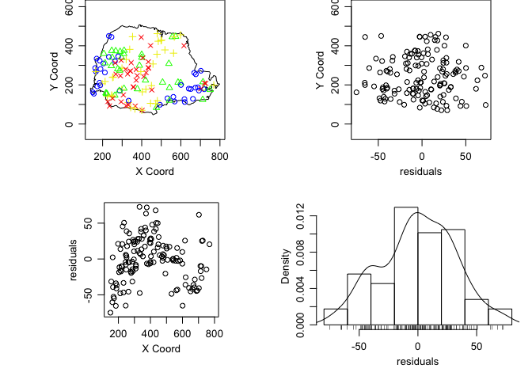

```r
plot(rf.gdf, trend = "1st")
```

2. Compute and plot an empirical variogram on the residuals after removing the 1st-order trend. Check for anisotropy.

```r
rf.v <- variog(rf.gdf,
                trend = "1st",
                max.dist = )
```

```
## variog: computing omnidirectional variogram
```

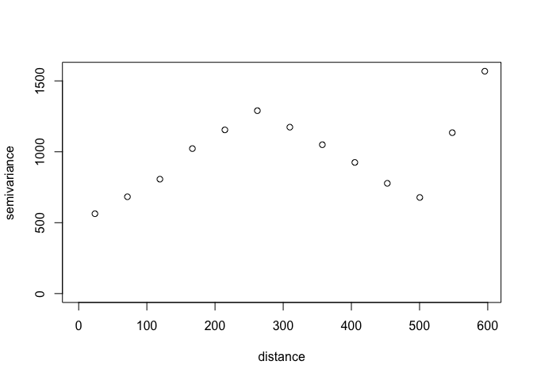

```r
plot(rf.v)
```

3. Fit a variogram model from the gaussian family to the empirical variogram. Assume isotropy. Set the initial values of the nugget to 500, the partial sill to 800 and the range to 100. Plot the modeled variogram on top of the empirical variogram.

```r
rf.vm <- likfit(rf.gdf,
                 trend = "1st",
                 ini = c(800, 100),
                 nug = 500,
                 cov.model = "gaussian")
```

```
## kappa not used for the gaussian correlation function
## ---------------------------------------------------------------
## likfit: likelihood maximisation using the function optim.
## likfit: Use control() to pass additional
##          arguments for the maximisation function.
##         For further details see documentation for optim.
## likfit: It is highly advisable to run this function several
##         times with different initial values for the parameters.
## likfit: WARNING: This step can be time demanding!
## ---------------------------------------------------------------
## likfit: end of numerical maximisation.
```

```r
rf.vm
```

```
## likfit: estimated model parameters:
##      beta0      beta1      beta2      tausq    sigmasq        phi
## "411.7512" " -0.1041" " -0.4283" "509.8989" "840.4501" "211.6516"
## Practical Range with cor=0.05 for asymptotic range: 366.3304
##
## likfit: maximised log-likelihood = -663.1
```

```r
plot(variog(rf.gdf, trend = "1st"))
```

```
## variog: computing omnidirectional variogram
```

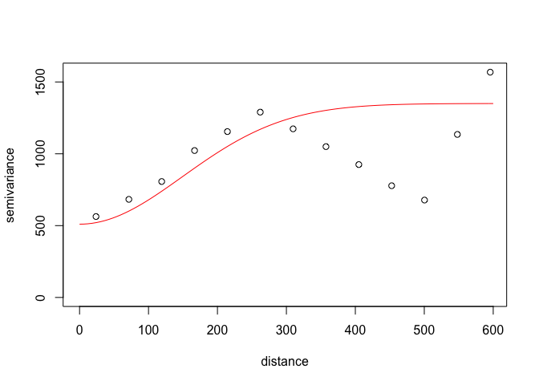

```r
lines.variomodel(cov.model = "gaussian",
                 cov.pars = c(840, 211),
                 nug = 510, max.dist = 600, col = "red")
```

4. Create a kriged surface by interpolating the rainfall values to locations on a regular grid. Use the `pred_grid(parana$borders, by = 2)` function to generate the grid.

```r
pgrid.df <- pred_grid(parana$borders, by = 2)
tail(pgrid.df)
```

```
##           Var1     Var2
## 76456 787.9873 506.7695
## 76457 789.9873 506.7695
## 76458 791.9873 506.7695
## 76459 793.9873 506.7695
## 76460 795.9873 506.7695
## 76461 797.9873 506.7695
```

```r
kc <- krige.conv(rf.gdf, loc = pgrid.df,
                  krige = krige.control(trend.d = "1st",
                                       trend.l = "1st",
                                       obj.m = rf.vm))
```

```
## krige.conv: results will be returned only for prediction locations inside the borders
## krige.conv: model with mean given by a 1st order polynomial on the coordinates
## krige.conv: Kriging performed using global neighbourhood
```

5. Plot the interpolated surface. Note this can be done with the `image()` function. Use `col = rev(terrain.colors(21))`.

```r
library(RandomFieldsUtils)
```

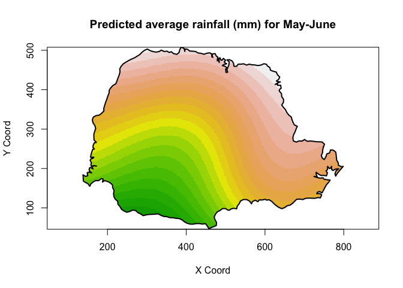

```r
image(kc, main = "Predicted average rainfall (mm) for May-June", col = rev(terrain.colors(21)))
```

6. Compute the cross-validated prediction errors assuming a constant variogram model. Plot the observed versus predicted values as a scatter plot. Include the best fit line and the y = x line.

```r
library(ggplot2)

xv.wk <- xvalid(rf.gdf, model = rf.vm)
```

```
## xvalid: number of data locations       = 143
## xvalid: number of validation locations = 143
## xvalid: performing cross-validation at location ... 1, 2, 3, 4, 5, 6, 7, 8, 9, 10, 11, 12, 13, 14, 15, 16, 17, 18, 19, 20, 21, 22, 23, 24, 25, 26, 27, 28, 29, 30, 31, 32, 33, 34, 35, 36, 37, 38, 39, 40, 41, 42, 43, 44, 45, 46, 47, 48, 49, 50, 51, 52, 53, 54, 55, 56, 57, 58, 59, 60, 61, 62, 63, 64…
## xvalid: end of cross-validation
```

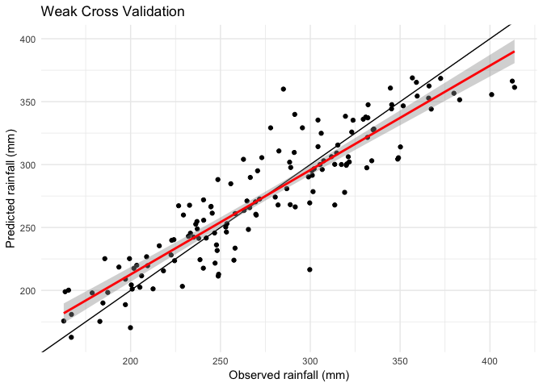

```r
df <- data.frame(observed = xv.wk$data, predicted = xv.wk$predicted)

ggplot(df, aes(x = observed, y = predicted)) +
  geom_point() +
  geom_abline(intercept = 0, slope = 1) +
  geom_smooth(method = lm, color = "red") +
  ylab("Predicted rainfall (mm)") +
  xlab("Observed rainfall (mm)") +
  ggtitle("Weak Cross Validation") +
  theme_minimal()
```

```r
mean(xv.wk$error^2)
```

```
## [1] 552.0396
```

```r
mean(abs(xv.wk$error))
```

```
## [1] 18.12003
```